# Data-tidying-lesson

Amanda B. Young

10/9/2019

```r
library(tidyr)
library(ggplot2)
library(dplyr)
```

To access `filter` from the `stats` package: `stats::filter()`

#Read in and clean up data

```r
catch_original <- read.csv(url("https://knb.ecoinformatics.org/knb/d1/mn/v2/object/df35b.302.1", method = "libcurl"),
                    stringsAsFactors = FALSE)
head(catch_original)
```

```
##   Region Year Chinook Sockeye Coho Pink Chum All notesRegCode
## 1    SSE 1886       0       5    0    0    0   5
## 2    SSE 1887       0     155    0    0    0 155
## 3    SSE 1888       0     224   16    0    0 240
## 4    SSE 1889       0     182   11   92    0 285
## 5    SSE 1890       0     251   42    0    0 292
## 6    SSE 1891       0     274   24    0    0 298
```

`stringsAsFactors` reads characters as factors rather than characters, keeps the future issues down Try to allways set `stingsAsFactors` to `FALSE`

Select the columns we want using the `select()`

```r
catch_data<-catch_original %>%
  #select(Region, Year, Chinook, Sockeye, Coho, Pink, Chum)
  select(-All, -notesRegCode)
head(catch_data)
```

```
##   Region Year Chinook Sockeye Coho Pink Chum
## 1    SSE 1886       0       5    0    0    0
## 2    SSE 1887       0     155    0    0    0
## 3    SSE 1888       0     224   16    0    0
## 4    SSE 1889       0     182   11   92    0
## 5    SSE 1890       0     251   42    0    0
## 6    SSE 1891       0     274   24    0    0
```

```r
summary(catch_data)
```

```
##     Region               Year        Chinook             Sockeye
##  Length:1708        Min.   :1878   Length:1708        Min.   :    0.00
##  Class :character   1st Qu.:1922   Class :character   1st Qu.:    6.75
##  Mode  :character   Median :1947   Mode  :character   Median :  330.50
##                     Mean   :1946                      Mean   : 1401.09
##                     3rd Qu.:1972                      3rd Qu.:  995.50
##                     Max.   :1997                      Max.   :44269.00
##       Coho             Pink              Chum
##  Min.   :   0.0   Min.   :    0.0   Min.   :    0.0
##  1st Qu.:   0.0   1st Qu.:    0.0   1st Qu.:    0.0
##  Median :  41.5   Median :   34.5   Median :   63.0
##  Mean   : 150.4   Mean   : 2357.8   Mean   :  422.0
##  3rd Qu.: 175.0   3rd Qu.: 1622.5   3rd Qu.:  507.5
##  Max.   :3220.0   Max.   :53676.0   Max.   :10459.0
```

Change the values in the CHinook column to numeric using `mutate()`

```r
catch_clean<- catch_data %>%
  mutate(Chinook=as.numeric(Chinook))
head(catch_clean)
```

```
##   Region Year Chinook Sockeye Coho Pink Chum
## 1    SSE 1886       0       5    0    0    0
## 2    SSE 1887       0     155    0    0    0
## 3    SSE 1888       0     224   16    0    0
## 4    SSE 1889       0     182   11   92    0
## 5    SSE 1890       0     251   42    0    0
## 6    SSE 1891       0     274   24    0    0
```

Investigate using `which()` and `is.na()`

```r
i<- which(is.na(catch_clean$Chinook))
i
```

```
## [1] 401
```

```r
catch_original[i,]
```

```
##     Region Year Chinook Sockeye Coho Pink Chum All notesRegCode
## 401    GSE 1955       I      66    0    0    1  68
```

- use `mutate` to change the I to 1
- use `mutate` to coerce Chinook column to numeric `%in%` can be used instead of `|` as an or when using ifelse

```r
catch_clean<-catch_data %>%
  #mutate(Chinook = ifelse(Chinook == "I"| Chinook =="l")) %>%
  mutate(Chinook = ifelse(Chinook  %in%  c("I", "l"), 1, Chinook)) %>%
  mutate(Chinook=as.numeric(Chinook))
head(catch_clean)
```

```
##   Region Year Chinook Sockeye Coho Pink Chum
## 1    SSE 1886       0       5    0    0    0
## 2    SSE 1887       0     155    0    0    0
## 3    SSE 1888       0     224   16    0    0
## 4    SSE 1889       0     182   11   92    0
## 5    SSE 1890       0     251   42    0    0
## 6    SSE 1891       0     274   24    0    0
```

# Tidy Data

Move from wide formate to tall format using `pivot_longer`

```r
catch_long<-catch_clean %>%
  pivot_longer(cols=-c(Region, Year),
               names_to = "Species",
               values_to = "Catch")
head(catch_long)
```

```
## # A tibble: 6 x 4
##   Region  Year Species Catch
##   <chr>  <int> <chr>   <dbl>
## 1 SSE     1886 Chinook     0
## 2 SSE     1886 Sockeye     5
## 3 SSE     1886 Coho        0
## 4 SSE     1886 Pink        0
## 5 SSE     1886 Chum        0
## 6 SSE     1887 Chinook     0
```

```r
catch_wide<-catch_long %>%
  pivot_wider(names_from = Species,
              values_from = Catch)
head(catch_wide)
```

```
## # A tibble: 6 x 7
##   Region  Year Chinook Sockeye  Coho  Pink  Chum
##   <chr>  <int>   <dbl>   <dbl> <dbl> <dbl> <dbl>
## 1 SSE     1886       0       5     0     0     0
## 2 SSE     1887       0     155     0     0     0
## 3 SSE     1888       0     224    16     0     0
## 4 SSE     1889       0     182    11    92     0
## 5 SSE     1890       0     251    42     0     0
## 6 SSE     1891       0     274    24     0     0
```

```r
catch_long<-catch_long %>%
  mutate(Catch=Catch*1000)
```

# Summarize Data

mean catch by region of Sockeye

```r
mean_region<-catch_long %>%
  group_by(Region) %>%
    filter(Species == "Sockeye") %>%
summarise(mean_catch=mean(Catch),
            n_obs=n())
head(mean_region)
```

```
## # A tibble: 6 x 3
##   Region mean_catch n_obs
##   <chr>       <dbl> <int>
## 1 ALU         6839.    87
## 2 BER        36882.   102
## 3 BRB     12516500    114
## 4 CHG       962600    110
## 5 CKI      1772952.   105
## 6 COP       699628.    94
```

total annual catch

```r
annual_catch<-catch_long %>%
  group_by(Year) %>%
  summarise(total_catch = sum(Catch)) %>%
  arrange(desc(total_catch))
annual_catch
```

```
## # A tibble: 120 x 2
##     Year total_catch
##    <int>       <dbl>
##  1  1995   217260000
##  2  1994   195882000
##  3  1993   193107000
##  4  1991   189520000
##  5  1996   176072000
##  6  1990   155058000
##  7  1989   154127000
##  8  1985   146359000
##  9  1992   136726000
## 10  1984   133964000
## # ... with 110 more rows
```

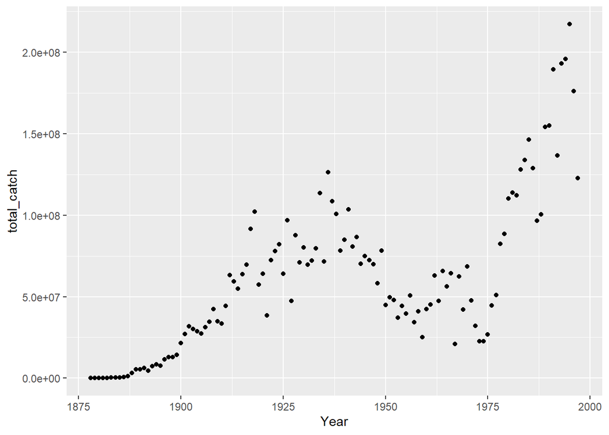

```r
ggplot(annual_catch, aes(x=Year, y=total_catch))+
  geom_point()
```

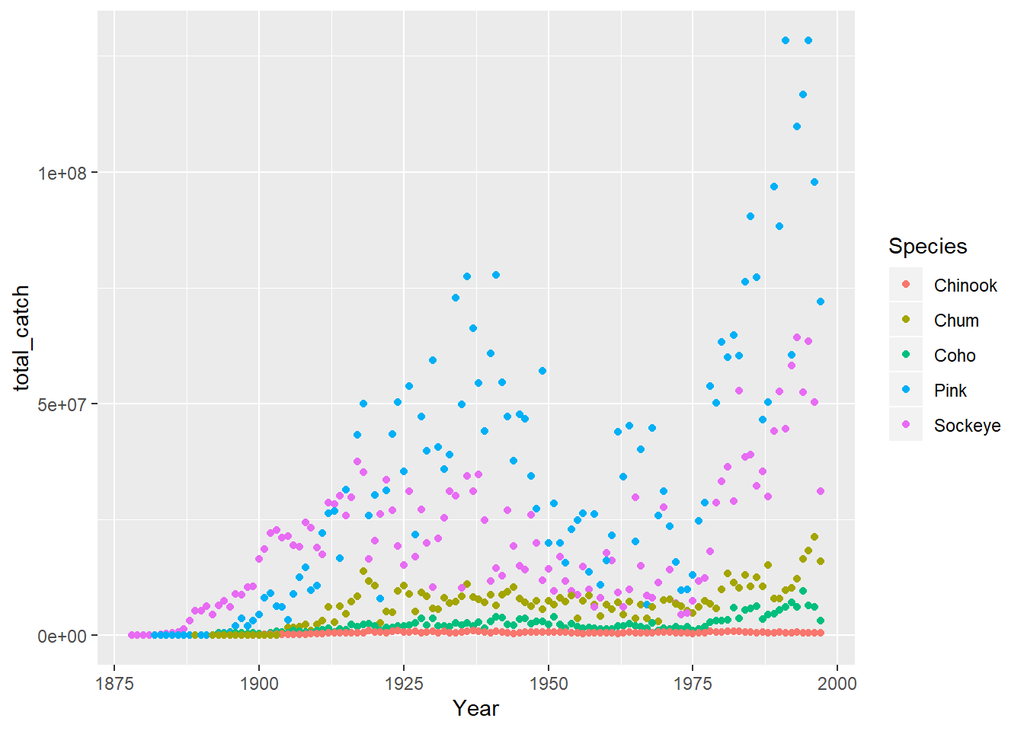

```r
catch_long %>%
  group_by(Year,Species) %>%
  summarise(total_catch = sum(Catch)) %>%
  arrange(desc(total_catch)) %>%
  ggplot(aes(x=Year, y=total_catch, colour=Species))+
  geom_point()
```

```r
region_defs<- read.csv(url("https://knb.ecoinformatics.org/knb/d1/mn/v2/object/df35b.303.1", method = "libcurl"),
                    stringsAsFactors = FALSE) %>%
  select(code, mgmtArea) %>%
  rename(Region = code)
head(region_defs)
```

```
##    Region                                  mgmtArea
## 1     GSE              Unallocated Southeast Alaska
## 2     NSE                 Northern Southeast Alaska
## 3     SSE                 Southern Southeast Alaska
## 4     YAK                                   Yakutat
## 5 PWSmgmt      Prince William Sound Management Area
## 6     BER Bering River Subarea Copper River Subarea
```

Create a join between catch and region files

```r
#catch_joined<-left_join(catch_long, region_defs, by=c("Region"= "code"))
catch_joined<-left_join(catch_long, region_defs, by="Region")
catch_joined<- left_join(catch_long, region_defs)
head(catch_joined)
```

```
## # A tibble: 6 x 5
##   Region  Year Species Catch mgmtArea
##   <chr>  <int> <chr>   <dbl> <chr>
## 1 SSE     1886 Chinook     0 Southern Southeast Alaska
## 2 SSE     1886 Sockeye  5000 Southern Southeast Alaska
## 3 SSE     1886 Coho        0 Southern Southeast Alaska
## 4 SSE     1886 Pink        0 Southern Southeast Alaska
## 5 SSE     1886 Chum        0 Southern Southeast Alaska
## 6 SSE     1887 Chinook     0 Southern Southeast Alaska
```

```r
dates_df <- data.frame(date = c("5/24/1930",
                                "5/25/1930",
                                "5/26/1930",
                                "5/27/1930",
                                "5/28/1930"),
                       stringsAsFactors = FALSE)

dates_df %>%
  separate(date, into = c("month", "day", "year"), sep = "/", remove = FALSE) %>%
  unite(date_2, year, month, day, sep="-")
```

```
##        date    date_2
## 1 5/24/1930 1930-5-24
## 2 5/25/1930 1930-5-25
## 3 5/26/1930 1930-5-26
## 4 5/27/1930 1930-5-27
## 5 5/28/1930 1930-5-28
```

can use substr to seperate a variable by the number of integers, also can use package `stringr::str_sub` to get the last few integers `string_pad` can say I want two digits but if I only have a 5 then it would become 05